# Impact des conférences d’Avenir Climatique

## Nombre de personnes sensibilisées

Du 1er août 2019 au 30 juin 2020, 1904 ont été sensibilisés.

On peut regarder l’évolution du nombre de spectateurs par an.

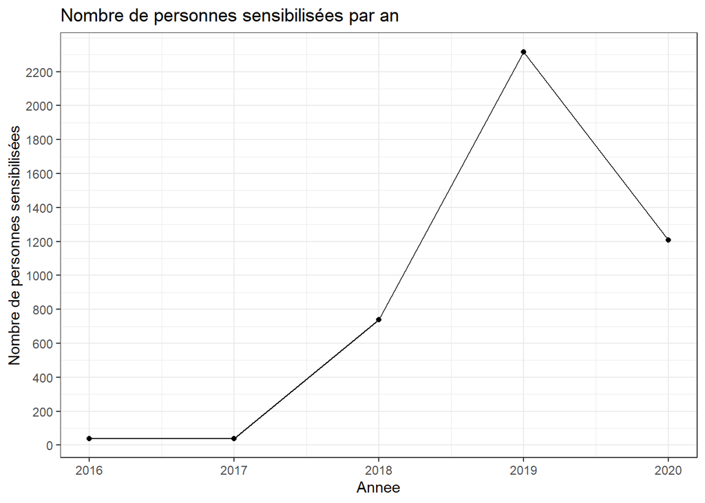

On note une forte augmentation du nombre de personnes sensibilisées. La chute observée en 2020 s’explique par la crise du Covid-19 qui a mis à mal certaines tenues de conférences.

En 2019, 2317 personnes ont assisté à des conférences d’Avenir Climatique.

Regardons le nombre de personnes sensibilisées par département (saison 2019-2020):

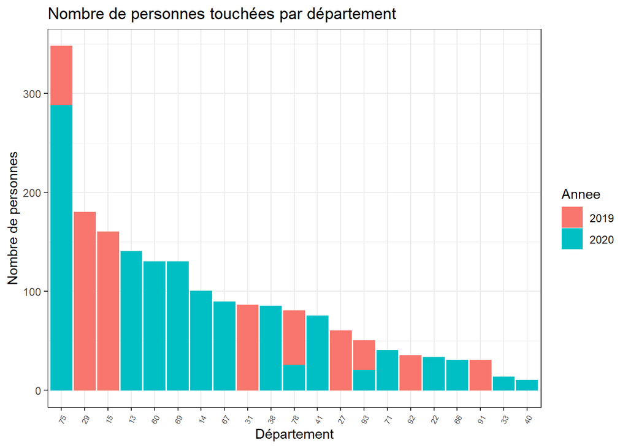

Les conférences ont principalement sensibilisé des parisiens, même si d’autres départements ont aussi eu pas mal de spectateurs (Finistère, Rhône etc.).

Voici une carte de France des spectateurs de la TBC.

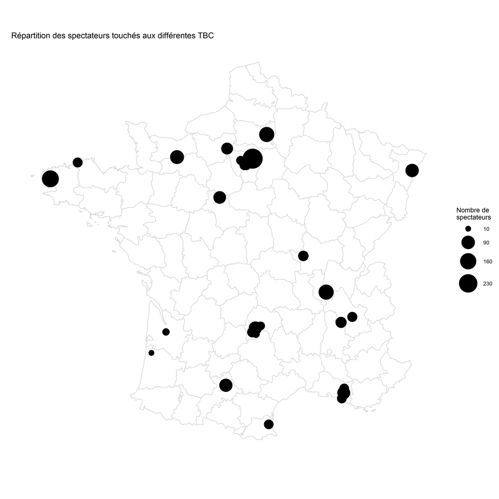

[output not shown]

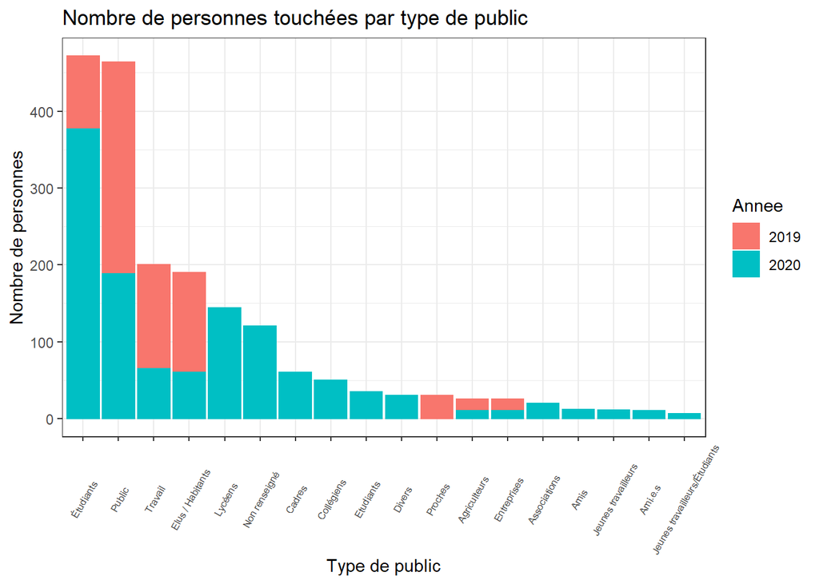

Les conférences sont principalement faites à des étudiant.e.s ou au grand public.

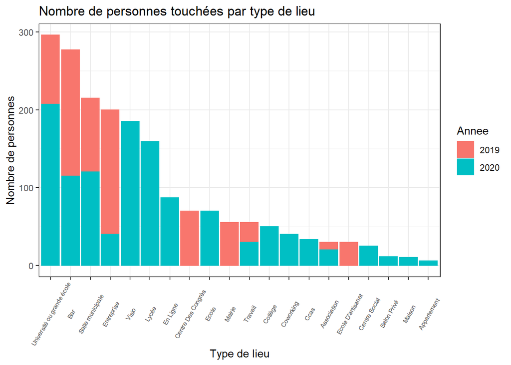

Enfin, quand on observe la répartition du nombre de personnes touchées par type de lieu, on retrouve le fort nombre d’étudiant.e.s sensibilisé.e.s dans les universités ou grandes écoles. On note également le fort nombre de personnes sensibilisées par visio, avec comme unique année 2020, année de la pandémie de Covid19.